# R pour les sciences marines — niveau avancé

Partie 2 · Séances A5 à A7 — SIG vecteur (sf), rasters (terra), cartes thématiques

Aroo Falinirina

## Au programme

- **A5** : données SIG vecteur avec `sf`
- **A6** : rasters avec `terra`
- **A7** : cartes thématiques (`ggplot2` + `sf`, `tmap`)

~25 min sf · ~20 min terra · ~15 min cartes. Montrer QGIS en parallèle si possible.

## A5 — sf

## Une couche = un data frame + une géométrie

```r
st_layers(gpkg)$name
```

```
#> [1] "land"           "mpa_zones"      "reef_sites"     "mangrove_plots"
```

```r
zones[1:3, c("mpa", "zone")]
```

```
#> Simple feature collection with 3 features and 2 fields
#> Geometry type: MULTIPOLYGON
#> Dimension:     XY
#> Bounding box:  xmin: 341703.7 ymin: 7480067 xmax: 361306.2 ymax: 7500064
#> Projected CRS: WGS 84 / UTM zone 38S
#>          mpa    zone                           geom
#> 1 Ankaramena Fishing MULTIPOLYGON (((359067.1 74...
#> 2 Ankaramena No-take MULTIPOLYGON (((361171.4 74...
#> 3 Ankaramena Fishing MULTIPOLYGON (((359734 7480...
```

- types : `POINT`, `LINESTRING`, `POLYGON` (+ `MULTI…`)
- formats : **GeoPackage** (1 fichier, plusieurs couches), shapefile (4+ fichiers !), CSV → `st_as_sf(coords = c("lon", "lat"), crs = 4326)`

## Systèmes de coordonnées

| SCR | EPSG | Unités | Usage |
| --- | --- | --- | --- |
| WGS84 | 4326 | degrés | GPS, web |
| UTM 38S | 32738 | mètres | surfaces, distances, tampons (SO de Madagascar) |

```r
c(zones = st_crs(zones)$epsg, villages = st_crs(villages)$epsg)
```

```
#>    zones villages
#>    32738     4326
```

```r
villages <- st_transform(villages, st_crs(zones))      # toujours le même SCR avant de combiner
```

## Mesurer et combiner

```r
zones$km2 <- as.numeric(st_area(zones)) / 1e6
tapply(zones$km2, zones$zone, sum) |> round(1)
```

```
#> Fishing No-take
#>   441.4   294.3
```

```r
belt <- st_buffer(st_union(filter(zones, zone == "No-take")), 2000)     # 2 km
villages$village[lengths(st_intersects(villages, belt)) > 0]
```

```
#> [1] "Antsiraka"  "Ampasimena" "Befasy"     "Andrevobe"  "Tsimanjaka"
```

`st_buffer`, `st_union`, `st_intersection`, `st_difference`, `st_distance`, `st_join`

## Jointure spatiale

```r
st_join(sites[1:4, "site_id"], zones[, c("mpa", "zone")]) |> st_drop_geometry()
```

```
#>   site_id        mpa    zone
#> 1     R01 Ankaramena No-take
#> 2     R02 Ankaramena No-take
#> 3     R03 Ankaramena No-take
#> 4     R04 Ankaramena Fishing
```

`group_by(mpa) |> summarise()` fusionne les polygones (« dissolve »).

## A6 — terra

## Un raster : une grille de valeurs

```r
bathy <- rast("data/advanced/bathymetry.tif"); sst <- rast("data/advanced/sst_2024.tif")
c(res = res(bathy)[1], cellules = ncell(bathy), couches_sst = nlyr(sst))
```

```
#>         res    cellules couches_sst
#>     2.5e-03     7.2e+04     1.2e+01
```

- étendue, résolution, SCR, couches, `NA`
- `crop()`, `mask()`, `project()` (bilinear / near), `classify()`
- algèbre cellule par cellule : `max(sst)`, `sum(sst > 29.5)`

## Extraire aux sites → relier au terrain

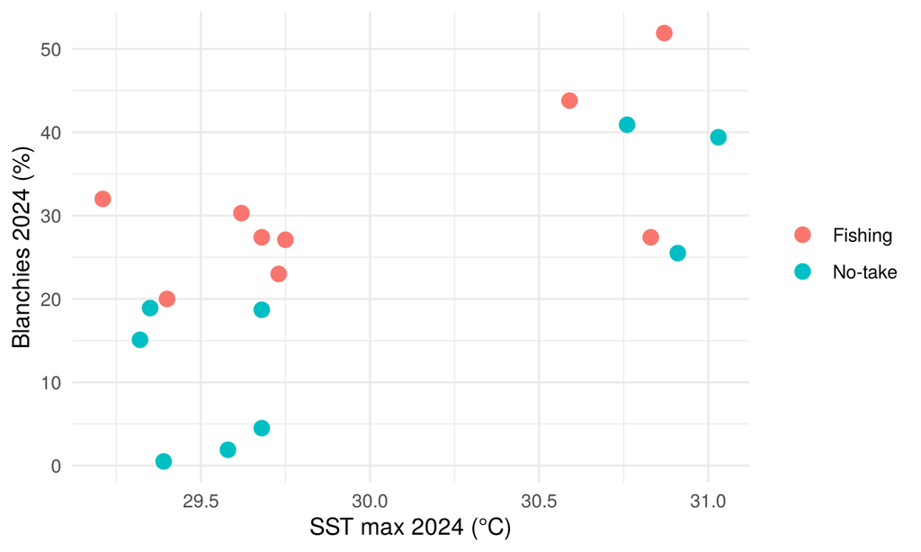

```r
sv <- vect(st_transform(sites, crs(sst)))
heat <- data.frame(site_id = sites$site_id, zone = sites$zone, sst_max = extract(max(sst), sv)[, 2]) |>
  left_join(reef |> filter(year == 2024) |> group_by(site_id) |> summarise(bl = mean(bleached_pct)), by = "site_id")
ggplot(heat, aes(sst_max, bl, colour = zone)) + geom_point(size = 3) +
  labs(x = "SST max 2024 (°C)", y = "Blanchies 2024 (%)", colour = NULL) + theme_minimal()
```

r = 0.65 : un **indice**, pas une preuve (18 sites, grille de 2 km).

## Statistiques zonales

```r
zs <- extract(bathy, vect(st_transform(zones, 4326)), fun = mean, na.rm = TRUE)
data.frame(mpa = zones$mpa, zone = zones$zone, prof = round(zs$depth_m, 1))[1:4, ]
```

```
#>           mpa    zone prof
#> 1  Ankaramena Fishing  9.7
#> 2  Ankaramena No-take 10.0
#> 3  Ankaramena Fishing 15.3
#> 4 Nosy Fasika Fishing 15.9
```

Une cellule de 270 m n’est pas votre point exact : profondeur mesurée ≠ profondeur interpolée.

## A7 — Cartes

## geom_sf + coord_sf

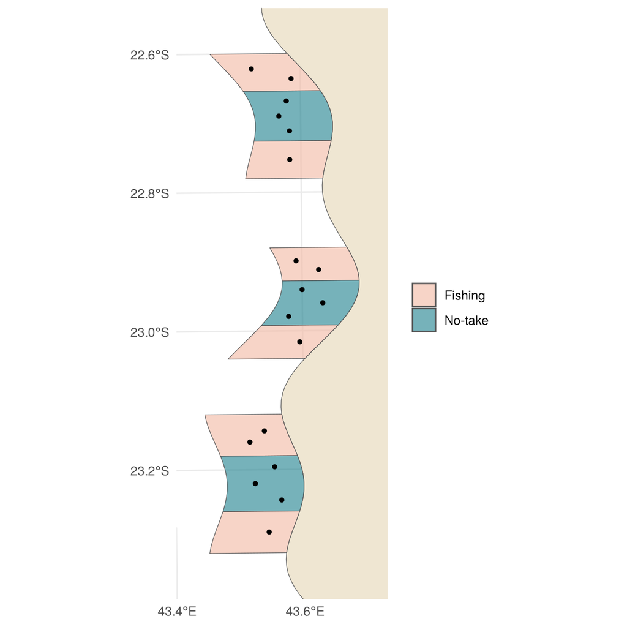

```r
ggplot() + geom_sf(data = land, fill = "#efe6d2") +
  geom_sf(data = zones, aes(fill = zone), alpha = .6) + geom_sf(data = sites, size = 1) +
  scale_fill_manual(values = c("No-take" = "#1b7f8c", "Fishing" = "#f2b8a2"), name = NULL) +
  coord_sf(xlim = bb[c(1, 3)], ylim = bb[c(2, 4)], datum = 4326) +
  scale_x_continuous(breaks = c(43.4, 43.6)) + theme_minimal()
```

## Règles d’une bonne carte

- **quoi, où, quand** dans le titre ou la légende
- légende avec **unités** ; **source** et **SCR** en bas
- barre d’échelle **en SCR projeté** + flèche du nord
- palette **séquentielle** (quantité), **divergente** (variation autour de 0), **qualitative** (catégories)
- 5 à 7 classes au maximum ; fond discret

## Rasters et tmap

- ggplot2 : `as.data.frame(r, xy = TRUE)` + `geom_raster()` (ou `tidyterra`)
- petits multiples : `facet_wrap(~ year)`
- **tmap 4** : `tm_shape() + tm_polygons(fill = ...) + tm_dots() + tm_scalebar() + tm_compass()`
- `tmap_mode("view")` → **carte interactive** avec le même code

```r
ggsave("outputs/figures/carte.png", width = 16, height = 20, units = "cm", dpi = 300)
```

## sf, terra, tmap : même idée, noms différents

| Tâche | sf / ggplot2 | terra / tmap |
| --- | --- | --- |
| SCR | `st_crs()` | `crs()` |
| reprojeter | `st_transform(x, crs)` | `project(x, y, method)` |
| statistique | `extract(..., fun = mean)` | `global(x, "mean")` (texte !) |
| écraser un fichier | `st_write(delete_dsn / append = FALSE)` | `writeRaster(overwrite = TRUE)` |
| colonne → couleur | `aes(fill = zone)` (sans guillemets) | `tm_polygons(fill = "zone")` (avec) |
| transparence | `alpha` | `fill_alpha` |

`crs` dans `st_as_sf()` **déclare** ; `crs` dans `st_transform()` **convertit**.

## À retenir — partie 2

- **même SCR** avant de combiner ; UTM pour mesurer en mètres
- `st_join()` et les prédicats répondent aux questions « où ? »
- `extract()` relie les rasters (télédétection) aux données de terrain
- une carte est une figure : titre, légende, échelle, source

**À faire** : séances A5 à A7 en ligne. Suite : Quarto, publication, exercices, projet final.